# Análise de Expressão diferencial de RNA-Seq com DESeq2

## Distribuição das read counts entre as replicatas.

[figure not shown]

```r
par(mfrow=c(1,2))
plot(countData[,1:2], xlab='day7_rep1', ylab='day4_rep1', pch=16, cex=0.5  )
plot(countData[,3:4], xlab='day7_rep2', ylab='day4_rep2', pch=16, cex=0.5  )

mtext("Comparando as distribuição das replicatas", line = -1.5, cex = 1.5, outer = TRUE)
```

Os dados acima revelam uma distribuição homogênea entre as reads das amostras. Qualificando as replicatas.

## Estimativa da Dispersão

Para um gene ter sua expressão significativa, não depende apenas de seu LFC, mas também de sua variabilidade dentro do grupo.

O DESeq2 quantifica esta dispersão que pode ser entendida como o coeficiente de variação ao quadrado. Por exemplo: um valor de dispersão de 0,01 significa que a expressão do gene tende a diferir normalmente em $\sqrt{0,01} = 10\%$ entre as amostras do mesmo grupo.

As estimativas de dispersão estão inversamente relacionadas à média e diretamente relacionadas à variância. Com base nessa relação, a dispersão de um gene é considerada alta quando a média das ‘readcounts’ são pequenas e uma dispersão baixa quando a média das ‘readCounts’ são maiores.

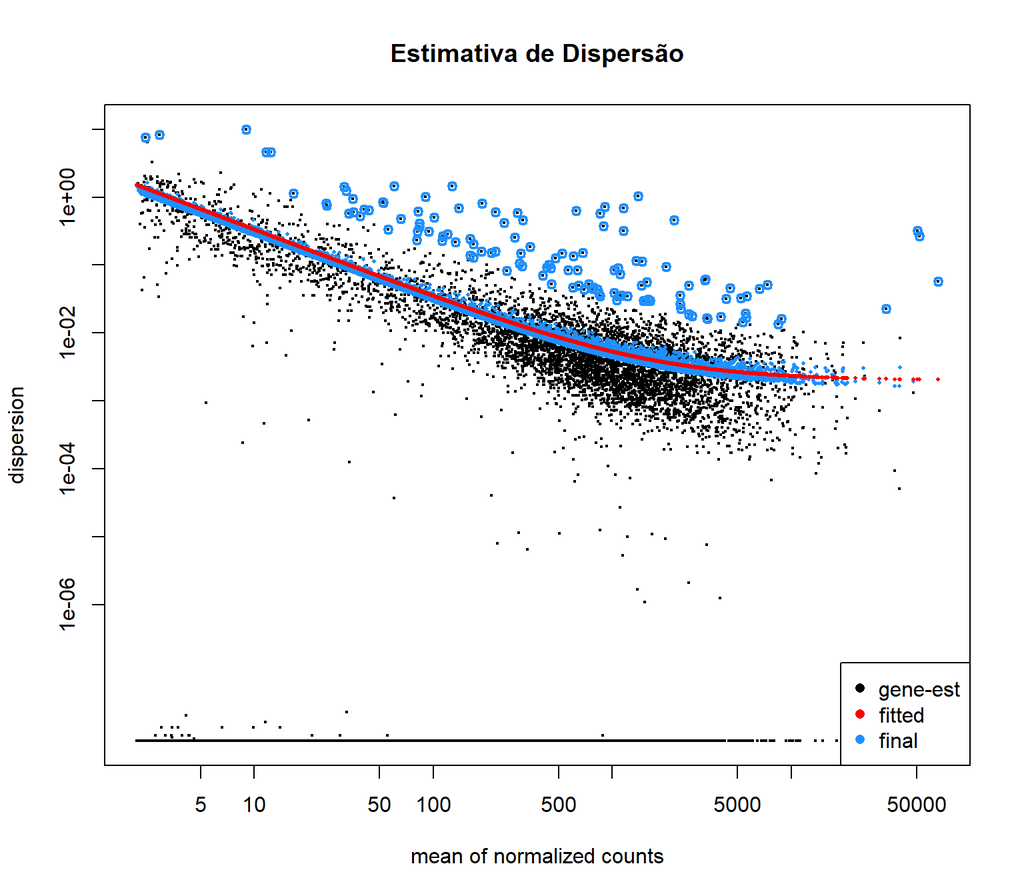

```r
plotDispEsts(ddsDE, main="Estimativa de Dispersão")
```

No gráfico de dispersão espera-se a dispersão dos genes analisados se encontrem próximo a linha de dispersão esperada.

- Os pontos pretos são as estimativas de dispersão para cada gene, obtidas considerando as informações de cada gene separadamente. (obs: A menos que se tenha muitas amostras, esses valores flutuam fortemente em torno de seus valores reais.)
- A linha vermelha representa a estimativa do valor de dispersão esperado para cada genes, que mostra a dependência das dispersões em relação à média.
- Os pontos azuis representam as estimativas finais, que são então usadas no teste de hipótese.
- Os círculos azuis acima da “nuvem” principal, são genes que possuem altas estimativas de dispersão (outliers da dispersão).

## PCA

Um gráfico de PCA mostra grupos de amostras com base em sua similaridade. O PCA não descarta nenhuma amostra ou característica (variáveis). Em vez disso, reduz o número esmagador de dimensões ao construir os componentes principais (PCs).

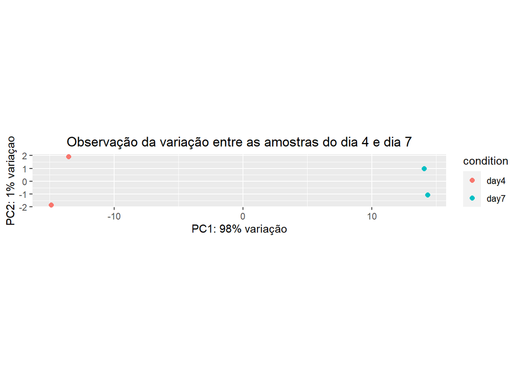

```r
pcaData <- plotPCA(rld, intgroup="condition", returnData=TRUE)

percentVar <- round(100 * attr(pcaData, "percentVar"))

ggplot(pcaData, aes(PC1, PC2, color=condition)) +
  geom_point(size=2) +
  ggtitle('Observação da variação entre as amostras do dia 4 e dia 7') +
  theme(plot.title = element_text(hjust = 0.5)) +

  xlab(paste0("PC1: ",percentVar[1],"% variação")) +
  ylab(paste0("PC2: ",percentVar[2],"% variaçao")) +
  coord_fixed()
```

## PCA 2

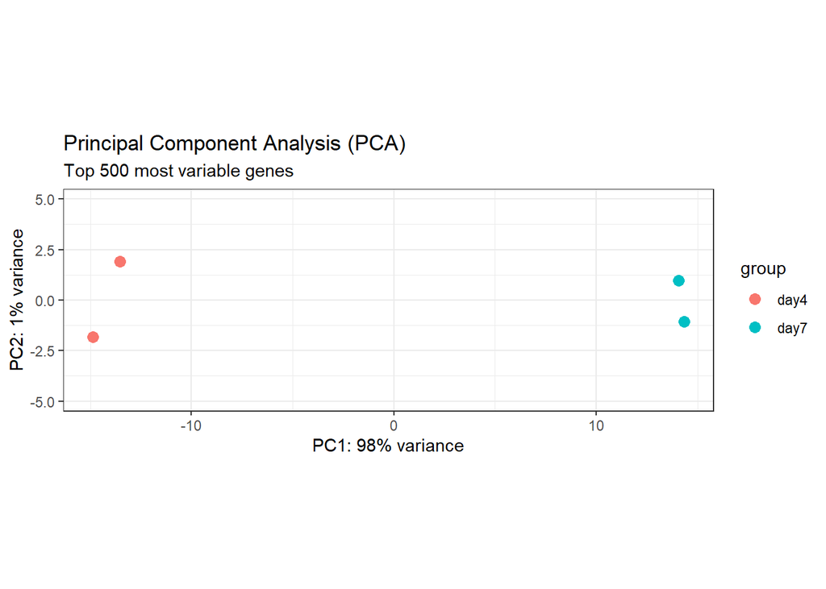

```r
# Plot PCA by column variable
plotPCA(rld, intgroup = "condition", ntop = 500) +
  theme_bw() + # remove default ggplot2 theme
  geom_point(size = 3) + # Increase point size
  scale_y_continuous(limits = c(-5, 5)) + # change limits to fix figure dimensions
  ggtitle(label = "Principal Component Analysis (PCA)",
          subtitle = "Top 500 most variable genes")
```

## Distância entre as amostras

Um heatmap da matriz de distância, nos dá uma visão geral sobre as semelhanças e dissimilaridades entre as amostras.

Este clustering de amostra é realizado ao aplicarmos a função dist() à transposta (t) da matriz de contagem transformada (rld) para obter distâncias amostra a amostra.

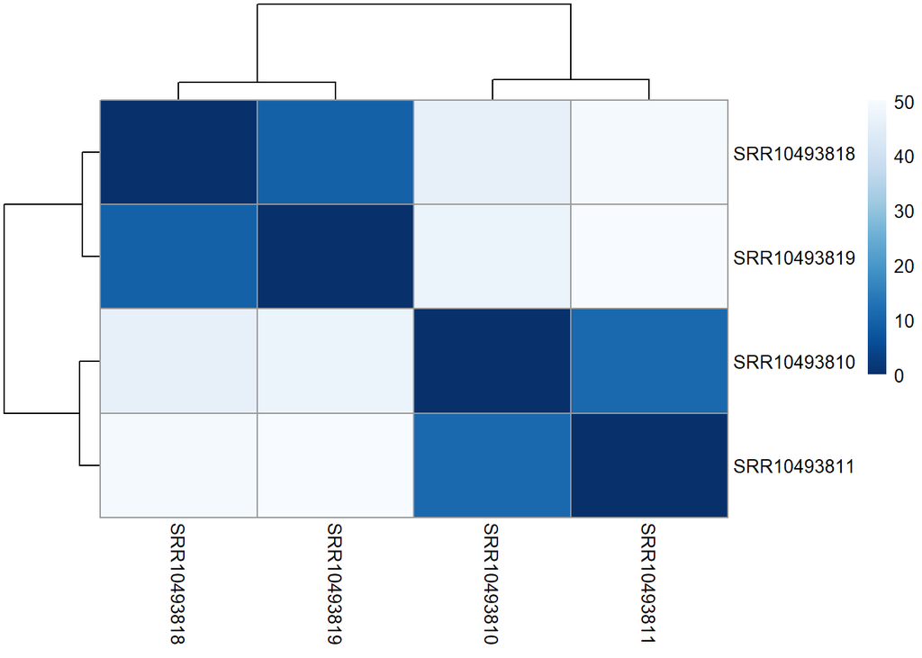

```r
sampleDists <- dist(t(assay_rld))

sampleDistMatrix <- as.matrix(sampleDists)
rownames(sampleDistMatrix) <- colnames(assay_rld)
colnames(sampleDistMatrix) <- colnames(assay_rld)

corBlues <- colorRampPalette(rev(brewer.pal(9, "Blues")))(255)

pheatmap(sampleDistMatrix,
         clustering_distance_rows=sampleDists,
         clustering_distance_cols=sampleDists,
         col=corBlues)
```

## Analisando os valores de p-value ajustado

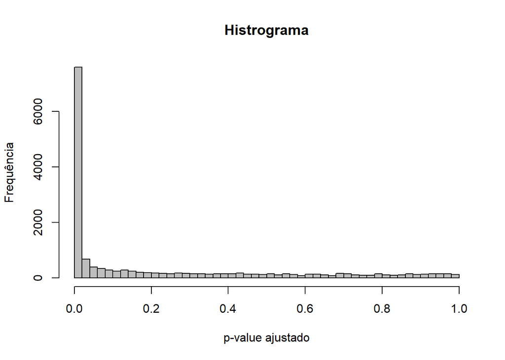

```r
hist(res05$padj, breaks=50, col="gray", main =('Histrograma'),
     xlab = 'p-value ajustado',
     ylab = 'Frequência')
```

## MA-Plot de LFCs vs contagens normalizadas

“MA-plot” (“M” para menos, porque uma razão de log é igual a log menos log, e “A” para média) é um gráfico de dispersão de LFC (log2 fold change, no eixo y) versus a média de contagens normalizadas (no eixo x).

A função plotMA mostra o LFC atribuíveis a uma determinada variável sobre a média das contagens normalizadas para todas as amostras no DESeqDataSet.

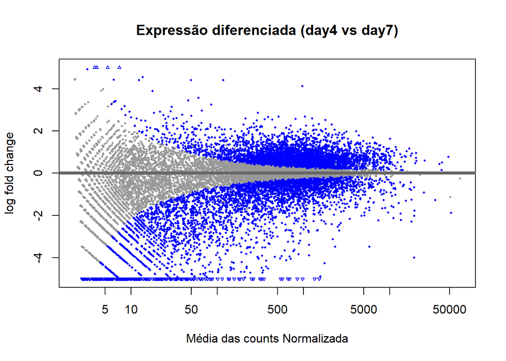

```r
plotMA(res05, ylim=c(-5,5), main='Expressão diferenciada (day4 vs day7)',
       xlab='Média das counts Normalizada',
       )
```

Cada ponto indica um gene, em azul temos os genes que estão diferencialmente expressos. sendo os acima da linha de marco zero ur-regulados e os abaixo down-regulados.

Obs: Os pontos que caem para fora da janela são plotados como triângulos abertos apontando para cima ou para baixo.

## Normalizando (shrink) os valores de log2 fold changes

Para gerar estimativas mais precisas de log2 foldchange, DESeq2 permite a redução das estimativas de LFC para zero quando a informação para um gene é baixa, como poucas readCounts ou altos valores de dispersão.

Esta redução ou normalização de LFC usa informações de todos os genes para gerar estimativas mais precisas. Especificamente, a distribuição das estimativas de LFC para todos os genes é usada para reduzir as estimativas de LFC de genes com poucas informações ou alta dispersão para estimativas de LFC mais prováveis (mais baixas).

Para gerar as estimativas de log2 fold change reduzidas, é preciso executar uma etapa adicional em seu objeto de resultados com a função lfcShrink ().

### A função lfcShrink () requer alguns parâmetros

objeto DESeqDataSet - ddsDE

Objeto DESeqResults - res05

Tipo do métodos - “apeglm” e “normal” e “ashr”:

O método apeglm requer o uso de coef. Já o método “normal”, tanto coef ou contrast podem ser especificado.

Obs: Apenas coef ou contrast pode ser especificado, não ambos.

coef = O nome( “condition_day7_vs_day4”) ou o número(indíce do resulteNames(), referente a condição a ser analizada, neste caso 2).

Consultando o resultsNames

```r
resultsNames(ddsDE)
```

```
## [1] "Intercept"              "condition_day7_vs_day4"
```

Caso o design do experimento tenha mais de uma condição, está pode ser acessada pelo seu indíce.

Para confirmar o número do coef:

```r
resultsNames(ddsDE)[2]
```

```
## [1] "condition_day7_vs_day4"
```

# Executando o lfcShrink()

OBS: A redução do LFC não mudará o número total de genes que são identificados como diferencialmente expressos.

A redução de LFC ajuda na avaliação posterior dos resultados, como na subdivisão de genes significativos com base em LFC para uma avaliação posterior.

Além disso, para ferramentas de análise funcional, como GSEA, que exigem valores de LFC como entrada, é necessário fornecer valores reduzidos.

```r
res05_shrink <- lfcShrink(ddsDE, coef=2, res=res05, type = "apeglm")
```

```
## using 'apeglm' for LFC shrinkage. If used in published research, please cite:
##     Zhu, A., Ibrahim, J.G., Love, M.I. (2018) Heavy-tailed prior distributions for
##     sequence count data: removing the noise and preserving large differences.
##     Bioinformatics. https://doi.org/10.1093/bioinformatics/bty895
```

## MA-Plot de LFCs dos lfc normalizadas

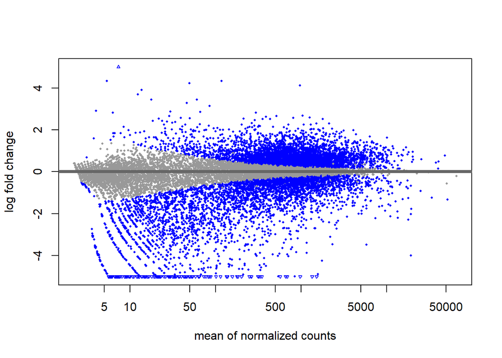

```r
plotMA(res05_shrink,  ylim=c(-5,5))
```

Comparando os plotMA dos valores de LFC reduzidos com os valores não reduzidos é possível notar uma abundância de pontos para os genes com baixas readcounts, e muitos destes com altos logfoldchanges, havendo uma alta dispersão nos valores de LFC. Apos a redução é possível observar um plot com estimativas mais reduzidas da dispesão, o que favorecerá as análises downstream.

## Plot counts

Pode ser útil examinar as contagens de leituras para um único gene entre os grupos. Uma função simples para fazer esse gráfico é plotCounts, que normaliza as contagens pelos fatores de tamanho estimados (ou fatores de normalização, se esses forem usados) e adiciona uma pseudocontagem de 1/2 para permitir a plotagem em escala logarítmica.

Aqui é representado o gene que teve o menor “p-value” da tabela de resultados(ddsDE). Obs: É possível selecionar o gene por nome ou por índice numérico.

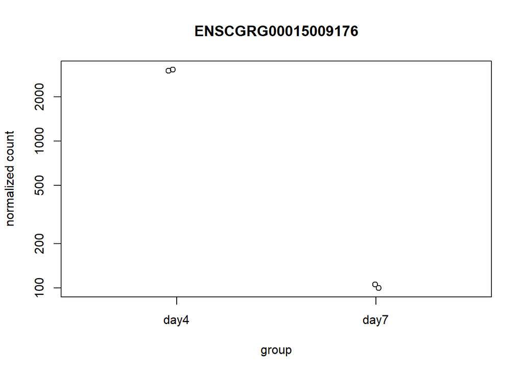

```r
gene_idx = which.min(res$padj)
plotCounts(ddsDE, gene=gene_idx, intgroup="condition")
```

# - - - - - - - - - - - - - - - - - - - - - - - - - - - - - - - - - - - - - - - - - - - - - - - - - - - - -

# Agrupamento de Genes e Visualização

# - - - - - - - - - - - - - - - - - - - - - - - - - - - - - - - - - - - - - - - - - - - - - - - - - - - - -

## Agrupamento de Genes e Visualização

Nosso propósito é a detecção de genes diferencialmente expressos, e estamos procurando em diferenças entre  
as amostras, da qual o tratamento experimental proporcionou mudanças no padrão controle .

Com isso, o heatmap tem o propósito de destacar as diferenças entre as amostras. Sendo sendo observada a  
variação da expressão de cada gene/linha em relação as amostras.

Sendo 0 a expressão média, enquanto, amarelo ou vermelho representam as diferenças do desvios padrão abaixo  
e acima dessa média, respectivamente. Um número absoluto mais alto, está relacionado a maior intensidade

### Z-score e o agrupamento das amostras

A padronização de scala por linha (scale=‘row’) centraliza os valores de expresão de cada gene e os  
transforma em Z-scores, e o heatmap mostra o quanto cada gene se desvia desta média.

Row Z-Score é um método de escalonamento para visualização em mapas de calor que ajuda a aprimorar os  
agrupamentos de genes com tendências semelhantes na expressão entre as amostras.

O Z-Score é calculado por: (Valor da expressão do gene na amostra de interesse) - (Expressão média em todas as amostras) / Desvio padrão

### Heatmap da matriz de contagem

Para explorar uma matriz de contagem, geralmente é instrutivo olhar para ela com um mapa de calor.

O mapa de calor se torna mais interessante se não olharmos para a expressão absoluta, mas sim para a quantidade que cada gene em uma amostra se desvia(uma anormalidade) da média dos genes em todas as amostras.

Portanto, os valores de cada gene nas amostras são reunidos em uma média e o heatmap mostra o quanto cada gene se desvia desta média.

### Agrupamento de genes pelo heatmap

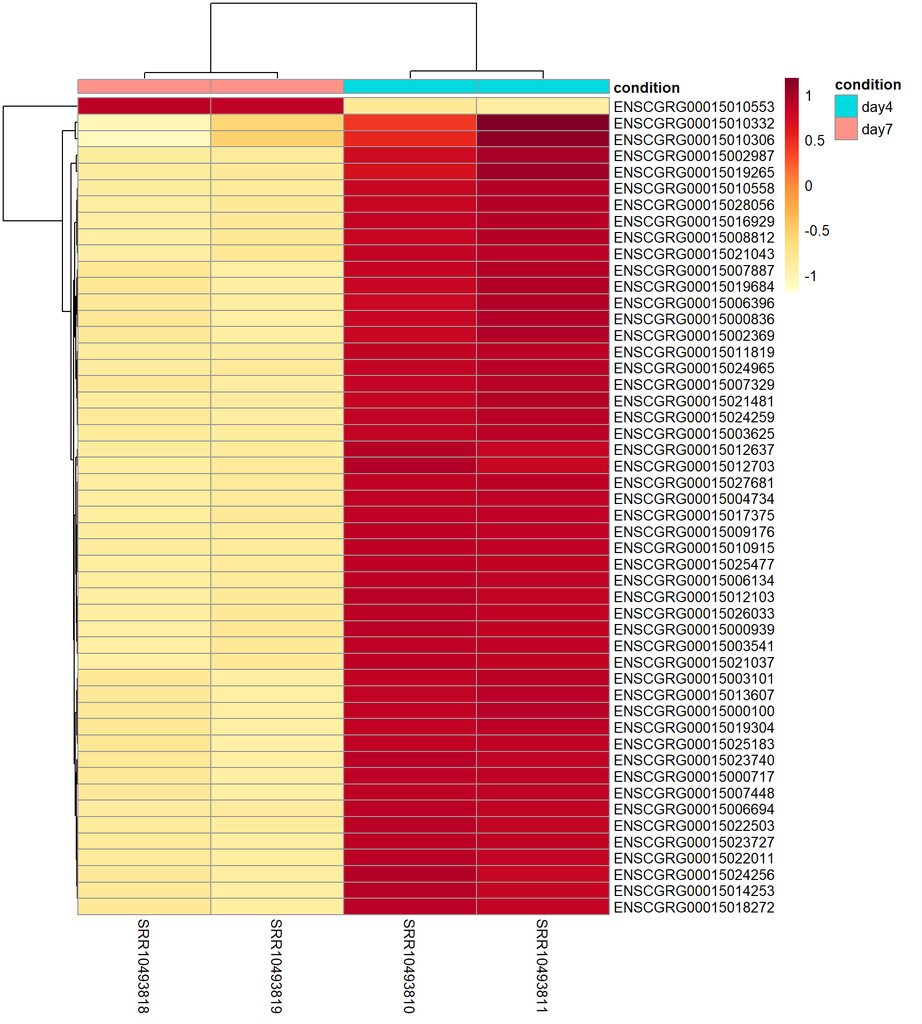

```r
topVarGenes <- head(order(-rowVars(assay_rld)),50) # - significa decresing

cores_heat<- colorRampPalette(brewer.pal(9, "YlOrRd"))(250)

mat <- assay_rld[ topVarGenes, ]
mat <- mat - rowMeans(mat)

pheatmap(mat, scale="row", cluster_rows=TRUE, show_rownames=TRUE,
         cluster_cols=TRUE, annotation_col=coldata, col=cores_heat)
```

## Volcano plot

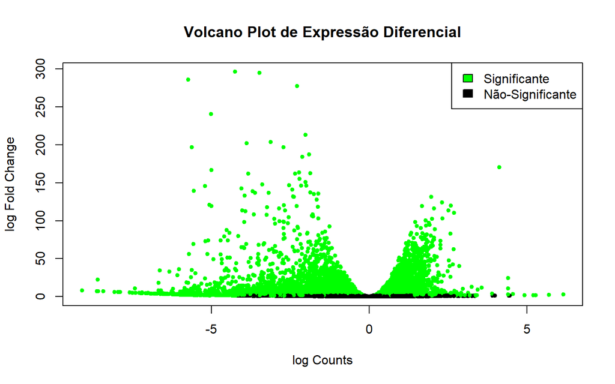

```r
#png("volcano-DE.png", 1000, 700, pointsize=20)

mylabel <- c('Significante', "Não-Significante")

plot(res05$log2FoldChange, -1*log10(res05$padj), col=ifelse(res05$padj<0.05, "green", "black"),
     xlab="log Counts", ylab="log Fold Change", pch=20, main='Volcano Plot de Expressão Diferencial')

legend('topright', mylabel, fill=c('green', 'black'))
```

# ———————————————————————————————————

# ———————————————————————————————————

## Adicionando uma coluna de significância em res05

Esta coluna receberá os valores de ‘True’ e ‘False’ se representarem dados significativos. Serão considerados valores significativos: pajd < 0.05 e logfoldchande > 0.5

OBS*: Lembrando que o resultado é expresso em log de 2, logo, log2 de 0.5 é igual a um log fold chande de 1.

```r
res05$significant <- ifelse(res05$padj< 0.05, "True", "False")
res05[which(abs(res05$log2FoldChange)< 0.5),'significant'] <- "False"
```

### Transformando a tabela res05 em df, para o merge com a tabela de dados homólogos de camundongos

```r
df_res05 <- as.data.frame(res05)

# Ordenando a tabela res05 pelo valor de p-value ajustado
df_res05 <- df_res05[order(res05$padj), ]

df_res05$Gene.stable.ID <- row.names(df_res05)

head(df_res05)
```

```
##                     baseMean log2FoldChange      lfcSE      stat        pvalue
## ENSCGRG00015009176  1570.408      -4.895201 0.12995594 -37.66816  0.000000e+00
## ENSCGRG00015021481  5834.333      -3.488346 0.08145884 -42.82342  0.000000e+00
## ENSCGRG00015012637 19362.170      -4.003034 0.07816005 -51.21585  0.000000e+00
## ENSCGRG00015003625  1754.204      -4.260218 0.11494741 -37.06232 1.137067e-300
## ENSCGRG00015006694  2341.466      -3.477787 0.09402772 -36.98683 1.864941e-299
## ENSCGRG00015027681  1519.005      -5.735843 0.15757490 -36.40074 4.143566e-290
##                             padj significant     Gene.stable.ID
## ENSCGRG00015009176  0.000000e+00        True ENSCGRG00015009176
## ENSCGRG00015021481  0.000000e+00        True ENSCGRG00015021481
## ENSCGRG00015012637  0.000000e+00        True ENSCGRG00015012637
## ENSCGRG00015003625 4.540310e-297        True ENSCGRG00015003625
## ENSCGRG00015006694 5.957367e-296        True ENSCGRG00015006694
## ENSCGRG00015027681 1.103017e-286        True ENSCGRG00015027681
```

## ovary cells)

```r
homoBiomart <- as.data.frame(read.delim('mart_export.txt', header = T, sep = '\t'))

head(homoBiomart)
```

```
##       Gene.stable.ID Mouse.gene.stable.ID
## 1 ENSCGRG00015000002
## 2 ENSCGRG00015000003
## 3 ENSCGRG00015000004
## 4 ENSCGRG00015000005
## 5 ENSCGRG00015000006   ENSMUSG00000021835
## 6 ENSCGRG00015000007   ENSMUSG00000037628
```

## Unindo os datasets pela coluna em comun gene.stable.ID

```r
results <- as.data.frame(merge(df_res05, homoBiomart, by='Gene.stable.ID'))

head(results)
```

```
##       Gene.stable.ID    baseMean log2FoldChange      lfcSE       stat
## 1 ENSCGRG00015000004    9.165919     -1.4670327 0.95825723 -1.5309383
## 2 ENSCGRG00015000005  223.298389      0.1961878 0.19946520  0.9835689
## 3 ENSCGRG00015000007 2491.435800      1.6823534 0.08987558 18.7186932
## 4 ENSCGRG00015000008 1734.822673      0.9511191 0.09468494 10.0450936
## 5 ENSCGRG00015000009 1695.826396      0.6720972 0.09511973  7.0658019
## 6 ENSCGRG00015000010  803.132818      0.1407853 0.12163216  1.1574678
##         pvalue         padj significant Mouse.gene.stable.ID
## 1 1.257846e-01 1.933249e-01       False
## 2 3.253275e-01 4.252501e-01       False
## 3 3.485988e-78 4.639851e-76        True   ENSMUSG00000037628
## 4 9.655602e-24 1.525413e-22        True   ENSMUSG00000015759
## 5 1.596911e-12 1.115254e-11        True   ENSMUSG00000062014
## 6 2.470813e-01 3.402905e-01       False   ENSMUSG00000055128
```

## Removendo dados duplicados

```r
# Removendo dados duplicados da Mouse.gene.stable.ID
results <- distinct(results, Mouse.gene.stable.ID, .keep_all= TRUE)

head(results)
```

```
##       Gene.stable.ID    baseMean log2FoldChange      lfcSE       stat
## 1 ENSCGRG00015000004    9.165919    -1.46703267 0.95825723 -1.5309383
## 2 ENSCGRG00015000007 2491.435800     1.68235343 0.08987558 18.7186932
## 3 ENSCGRG00015000008 1734.822673     0.95111913 0.09468494 10.0450936
## 4 ENSCGRG00015000009 1695.826396     0.67209715 0.09511973  7.0658019
## 5 ENSCGRG00015000010  803.132818     0.14078532 0.12163216  1.1574678
## 6 ENSCGRG00015000011  541.342367     0.02971783 0.14960944  0.1986361
##         pvalue         padj significant Mouse.gene.stable.ID
## 1 1.257846e-01 1.933249e-01       False
## 2 3.485988e-78 4.639851e-76        True   ENSMUSG00000037628
## 3 9.655602e-24 1.525413e-22        True   ENSMUSG00000015759
## 4 1.596911e-12 1.115254e-11        True   ENSMUSG00000062014
## 5 2.470813e-01 3.402905e-01       False   ENSMUSG00000055128
## 6 8.425474e-01 8.869154e-01       False   ENSMUSG00000021838
```

## Informações sobre os dados de entrada para a query.

keys: É coluna da tabela results que possui a key correspondente no do db que se deseja comparar e extrair os item.

column: Add colunas do db que se deseja adquirir as info. ex: c(“GO” , “SYMBOL”, “GENENAME” )

keytype: é o tipo de keys que estamos passando, nesse caso foi keytype = “ENSEMBL”, pois o id dos meus genes possuim essa nomeclatura.

### Consultar as colunas do db

```r
columns(org.Mm.eg.db)
```

```
##  [1] "ACCNUM"       "ALIAS"        "ENSEMBL"      "ENSEMBLPROT"  "ENSEMBLTRANS"
##  [6] "ENTREZID"     "ENZYME"       "EVIDENCE"     "EVIDENCEALL"  "GENENAME"
## [11] "GENETYPE"     "GO"           "GOALL"        "IPI"          "MGI"
## [16] "ONTOLOGY"     "ONTOLOGYALL"  "PATH"         "PFAM"         "PMID"
## [21] "PROSITE"      "REFSEQ"       "SYMBOL"       "UNIPROT"
```

### Consultar as keys do db

```r
keytypes(org.Mm.eg.db)
```

```
##  [1] "ACCNUM"       "ALIAS"        "ENSEMBL"      "ENSEMBLPROT"  "ENSEMBLTRANS"
##  [6] "ENTREZID"     "ENZYME"       "EVIDENCE"     "EVIDENCEALL"  "GENENAME"
## [11] "GENETYPE"     "GO"           "GOALL"        "IPI"          "MGI"
## [16] "ONTOLOGY"     "ONTOLOGYALL"  "PATH"         "PFAM"         "PMID"
## [21] "PROSITE"      "REFSEQ"       "SYMBOL"       "UNIPROT"
```

## Adicionando as anotações à tabela de resultados

```r
# Adicionando o símbolo do gene
results$GeneSymbol <- mapIds(x = org.Mm.eg.db,
                              keys = results$Mouse.gene.stable.ID,
                              column = "SYMBOL",
                              keytype = "ENSEMBL",
                              multiVals = "first")
# Adicionando a descrição do gene
results$GeneDescription <- mapIds(org.Mm.eg.db,
                              keys = results$Mouse.gene.stable.ID,
                              column = "GENENAME",
                              keytype = "ENSEMBL",
                              multiVals = "first")
# Adicionando o ENTREZID
results$ENTREZID <- mapIds(org.Mm.eg.db,
                              keys = results$Mouse.gene.stable.ID,
                              column = "ENTREZID",
                              keytype = "ENSEMBL",
                              multiVals = "first")
```

## Visualizando a tabela com os dados de anotação inseridos

```r
head(results)
```

```
##       Gene.stable.ID    baseMean log2FoldChange      lfcSE       stat
## 1 ENSCGRG00015000004    9.165919    -1.46703267 0.95825723 -1.5309383
## 2 ENSCGRG00015000007 2491.435800     1.68235343 0.08987558 18.7186932
## 3 ENSCGRG00015000008 1734.822673     0.95111913 0.09468494 10.0450936
## 4 ENSCGRG00015000009 1695.826396     0.67209715 0.09511973  7.0658019
## 5 ENSCGRG00015000010  803.132818     0.14078532 0.12163216  1.1574678
## 6 ENSCGRG00015000011  541.342367     0.02971783 0.14960944  0.1986361
##         pvalue         padj significant Mouse.gene.stable.ID GeneSymbol
## 1 1.257846e-01 1.933249e-01       False                            NULL
## 2 3.485988e-78 4.639851e-76        True   ENSMUSG00000037628      Cdkn3
## 3 9.655602e-24 1.525413e-22        True   ENSMUSG00000015759      Cnih1
## 4 1.596911e-12 1.115254e-11        True   ENSMUSG00000062014       Gmfb
## 5 2.470813e-01 3.402905e-01       False   ENSMUSG00000055128     Cgrrf1
## 6 8.425474e-01 8.869154e-01       False   ENSMUSG00000021838      Samd4
##                                      GeneDescription ENTREZID
## 1                                               NULL     NULL
## 2                cyclin-dependent kinase inhibitor 3    72391
## 3 cornichon family AMPA receptor auxiliary protein 1    12793
## 4                       glia maturation factor, beta    63985
## 5    cell growth regulator with ring finger domain 1    68755
## 6            sterile alpha motif domain containing 4    74480
```

## Criando um subset dos genes com expressão significativa

```r
res_sig = as.data.frame(subset(results, padj< 0.05))
res_sig <- na.omit(res_sig)
res_sig = res_sig[order(res_sig$log2FoldChange, decreasing=TRUE),]
head(res_sig)
```

```
##           Gene.stable.ID   baseMean log2FoldChange     lfcSE      stat
## 10631 ENSCGRG00015023276   3.770296       5.197611 1.9787167  2.626758
## 6361  ENSCGRG00015014056 117.023468       4.401428 0.4133496 10.648197
## 10027 ENSCGRG00015021957  49.390020       4.395877 0.6319612  6.955929
## 4838  ENSCGRG00015010553 975.317910       4.122989 0.1466262 28.119055
## 4839  ENSCGRG00015010553 975.317910       4.122989 0.1466262 28.119055
## 1606  ENSCGRG00015003447  60.584781       3.557383 0.4881616  7.287306
##              pvalue          padj significant Mouse.gene.stable.ID GeneSymbol
## 10631  8.620252e-03  1.834057e-02        True   ENSMUSG00000047953        Gp5
## 6361   1.777749e-26  3.293992e-25        True   ENSMUSG00000109392     Gm5737
## 10027  3.502474e-12  2.367394e-11        True   ENSMUSG00000024810       Il33
## 4838  5.729765e-174 5.719738e-171        True   ENSMUSG00000058427      Cxcl2
## 4839  5.729765e-174 5.719738e-171        True   ENSMUSG00000029379      Cxcl3
## 1606   3.162151e-13  2.348019e-12        True   ENSMUSG00000056758      Hmga2
##                        GeneDescription ENTREZID
## 10631        glycoprotein 5 (platelet)    14729
## 6361               predicted gene 5737   436008
## 10027                   interleukin 33    77125
## 4838  chemokine (C-X-C motif) ligand 2    20310
## 4839  chemokine (C-X-C motif) ligand 3   330122
## 1606     high mobility group AT-hook 2    15364
```

# Volcano Plot

Visualização dos gene com um p-value ajustado de <1e-50 e log2FoldChange absoluto > 2.

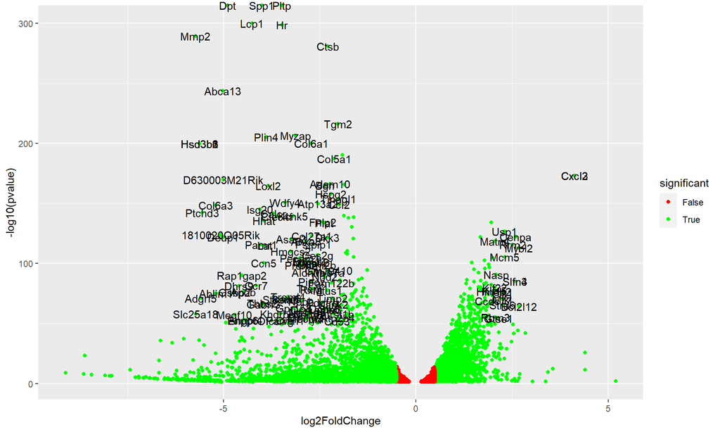

```r
library(ggrepel)

volcano = ggplot(res_sig, aes(log2FoldChange, -log10(pvalue))) + geom_point(aes(col=significant)) +
  scale_color_manual(values=c("red", "green"))

volcano + geom_text(data=filter(res_sig, abs(log2FoldChange) > 2 & padj <1e-50), aes(label=GeneSymbol)) +
  coord_cartesian(clip = "off")
```

## Salvando o arquivo resultados mais anotação

As colunas GeneSymbol, GeneDescription e ENTREZID, apresentam volores no formato lista. Durante a conversão para dataframe, para salvar como csv ou xlsm, o o programa não sabe como lidar com esse formato, salvando o arquivo sem estas iinformações.

Por isso é preciso converter as colunas para o tipo caracter, e aí sim salvar como dataframe no formato desejado.

```r
# Criando uma cópia do df
df <- res_sig
# Aplicando a função as.character as colunas GeneSymbol, GeneDescription e ENTREZID c(10:12)
alter_cols <- apply(df[ , c(10:12)], 2, as.character)  # retorna um df com as colunas modificadas

# Substituindo as colunas
df[ , colnames(df) %in% colnames(alter_cols)] <- alter_cols

# Salvando os resultados do DESeq2
write.csv(as.data.frame(df), 'results_DESeq2_annotation.csv')
writexl::write_xlsx(as.data.frame(df), 'results_DESeq2_annotation.xlsx')

# Sanvando os resultados DE para e up regulados down regulados
res05_sig_up <- filter(df, significant == "True" & log2FoldChange > 0)
writexl::write_xlsx(as.data.frame(res05_sig_up), 'results_DESeq2_genes_up.xlsx')

res05_sig_down <- filter(df, significant == "True" & log2FoldChange < 0)
writexl::write_xlsx(as.data.frame(res05_sig_down), 'results_DESeq2_genes_down.xlsx')
```

#————————————————————————————————————# # Opcional a critério do usuário #————————————————————————————————————#

```r
# Criando coluna de significância
res05_shrink$significant <- ifelse(res05_shrink$padj< 0.05, "True", "False")
res05_shrink[which(abs(res05_shrink$log2FoldChange)< 0.5),'significant'] <- "False"

# Transfornado o df_res05_shrink em dataframe
df_res05_shrink <- as.data.frame(res05_shrink)

# Ordenando a tabela res05 pelo valor de p-value ajustado
df_res05_shrink <- df_res05_shrink[order(df_res05_shrink$padj), ]

# Adicionando a coluna Gene.stable.ID como nome das linhas
df_res05_shrink$Gene.stable.ID <- row.names(df_res05_shrink)

# Realizando o merge do df_res05_shrink com genes id homólogos de camundongos
results2 <- as.data.frame(merge(df_res05_shrink, homoBiomart, by='Gene.stable.ID'))

# Removendo dados duplicados da Mouse.gene.stable.ID
results2 <- distinct(results2, Mouse.gene.stable.ID, .keep_all= TRUE)

### Adicionando as anotações à tabela de results2

# Adicionando o símbolo do gene
results2$GeneSymbol <- mapIds(x = org.Mm.eg.db,
                              keys = results$Mouse.gene.stable.ID,
                              column = "SYMBOL",
                              keytype = "ENSEMBL",
                              multiVals = "first")
# Adicionando a descrição do gene
results2$GeneDescription <- mapIds(org.Mm.eg.db,
                              keys = results$Mouse.gene.stable.ID,
                              column = "GENENAME",
                              keytype = "ENSEMBL",
                              multiVals = "first")
# Adicionando o ENTREZID
results2$ENTREZID <- mapIds(org.Mm.eg.db,
                              keys = results$Mouse.gene.stable.ID,
                              column = "ENTREZID",
                              keytype = "ENSEMBL",
                              multiVals = "first")
# Criando uma tabela de resultados significantes
res_sig2 = as.data.frame(subset(results2, padj< 0.05))
res_sig2 <- na.omit(res_sig2)
res_sig2 = res_sig2[order(res_sig2$log2FoldChange, decreasing=TRUE),]
```

### Conferindo os resultados com o Volcano Plot

Visualização dos gene com um p-value ajustado de <1e-50 e log2FoldChange absoluto > 2.

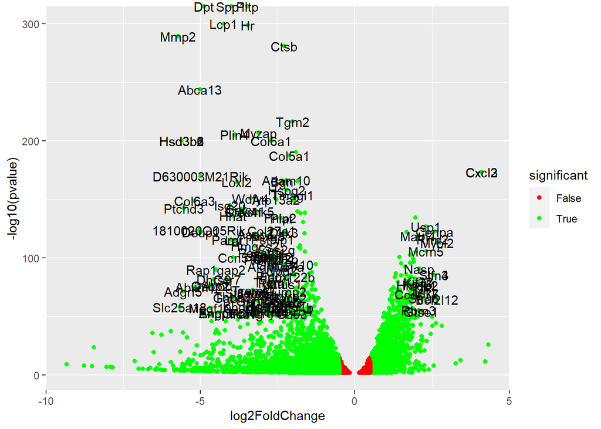

```r
volcano2 = ggplot(res_sig2, aes(log2FoldChange, -log10(pvalue))) + geom_point(aes(col=significant)) +
  scale_color_manual(values=c("red", "green"))

volcano2 + geom_text(data=filter(res_sig2, abs(log2FoldChange) > 2 & padj< 1e-50), aes(label=GeneSymbol)) +
  coord_cartesian(clip = "off")
```

## Normalizando os dados e salvando os resultados em um arquivo excel

Com a tabela dos resultados do DESeq2 com as anotações é possível continuar as análises downstream, como as análises de enriquecimento das vias, sem a necessidade de executar o deseq e a anotações gênica novamente.

### readCounts

```r
## Salvando a tabela readCounts não normalizada
#write.csv(counts, 'counsts.csv')

# Normalizando as counts
# norm_counts <- counts(ddsDE, normalized=TRUE)

# Salvando counts normaliadas
#write.csv(as.data.frame(norm_counts), 'norm_Counts.csv')
#write.csv(as.data.frame(assay_rld), 'rld_norm_Counts.csv')
```

### Resultados DESeq2 shrink

```r
# Salvando o resultado de deseq2 com p-value de 0,05
#write.csv(as.data.frame(res05), 'res05.csv')

# Criando uma cópia do df
df2 <- res_sig2

# Aplicando a função as.character as colunas GeneSymbol, GeneDescription e ENTREZID c(10:12)
alter_cols2 <- apply(df2[ , c(9:11)], 2, as.character)  # retorna um df com as colunas modificadas

# Substituindo as colunas
df2[ , colnames(df2) %in% colnames(alter_cols2)] <- alter_cols2

# Salvando os resultados do DESeq2
write.csv(as.data.frame(df2), 'results_DESeq2_shrink.csv')
writexl::write_xlsx(as.data.frame(df2), 'results_DESeq2_shrink.xlsx')

# Sanvando os resultados DE para e up regulados down regulados
res05_shrink_sig_up <- filter(df2, significant == "True" & log2FoldChange > 0)
writexl::write_xlsx(as.data.frame(res05_shrink_sig_up), 'results_DESeq2_shrink_genes_up.xlsx')

res05_shrink_sig_down <- filter(df2, significant == "True" & log2FoldChange < 0)
writexl::write_xlsx(as.data.frame(res05_shrink_sig_down), 'results_DESeq2_shrink_genes_down.xlsx')
```

## Referências

Love, M.I., Huber, W. & Anders, S. Moderated estimation of fold change and dispersion for RNA-seq data with DESeq2. Genome Biol 15, 550 (2014).

[Paper DESeq2](https://genomebiology.biomedcentral.com/articles/10.1186/s13059-014-0550-8)

[hbctraining DGE_Workshop_lessons](https://hbctraining.github.io/DGE_workshop/lessons/05_DGE_DESeq2_analysis2.html)

[hbctraining DGE_Workshop_salmon](https://hbctraining.github.io/DGE_workshop_salmon_online/lessons/05b_wald_test_results.html)

[Bioconductor vignettes DESeq2](https://bioconductor.org/packages/devel/bioc/vignettes/DESeq2/inst/doc/DESeq2.html#principal-component-plot-of-the-samples)

[Bioconductor vignettes rnaseq](https://www.bioconductor.org/packages/devel/workflows/vignettes/rnaseqGene/inst/doc/rnaseqGene.html)

[Bioconductor course material](https://www.bioconductor.org/help/course-materials/2015/LearnBioconductorFeb2015/B02.1.1_RNASeqLab.html)

[STHDA rna-seq workflow](http://www.sthda.com/english/wiki/rna-seq-differential-expression-work-flow-using-deseq2#diagnostic-plot)

#————————————————————————————————————# # FIM #————————————————————————————————————#